# compile-regional-data

### 2.2.6 Central Coast

#### Chinook

For Central Coast Chinook, the PSC’s Chinook Technical Committee (CTC) reported escapement for two indicator stocks on the Central Coast: the Atnarko River and Rivers Inlet (Chinook Technical Committee 2025). Rivers Inlet is monitored “using an index of escapements to the Wannock, Kilbella, and Chuckwalla rivers” (Chinook Technical Committee 2025). Because monitoring of Central Coast Chinook reported in NuSEDS has recently declined, expansions from spawner surveys are unreliable. As such, in 2025 we moved to using a composite indicator equal to the sum of the Atnarko River (`Total esc.`) and Rivers Inlet index reported by the CTC in Appendix Table B3.

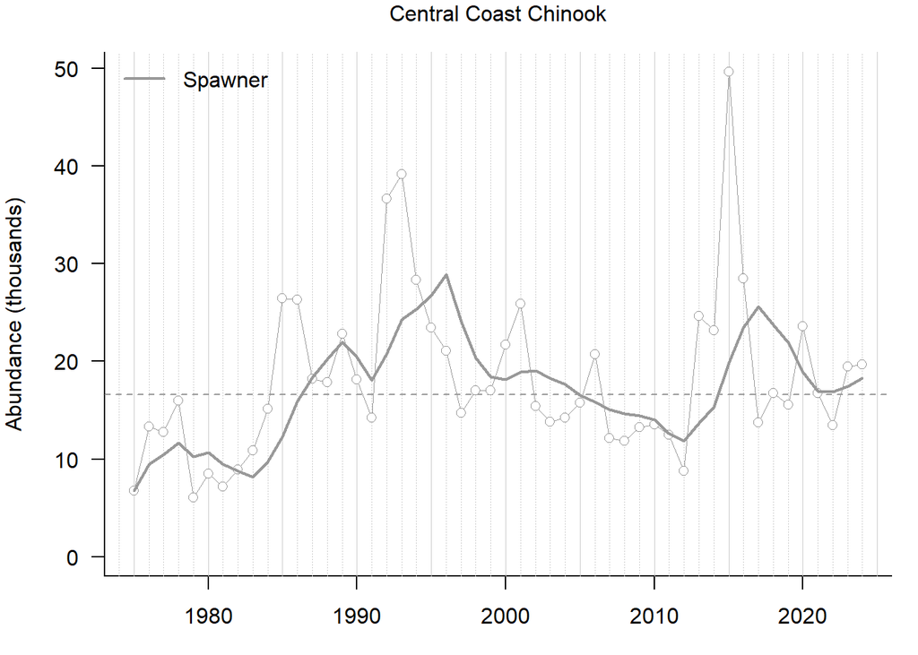

**Above:**Spawner abundance of Central Coast chinook salmon. The raw data is shown by points and the smoothed metric by solid lines. Dashed horizonal lines represent the long-term average.

```r
## Load data ---
# TCCHINOOK Table B3
cc_ctc <- readxl::read_xlsx("../data/TCCHINOOK-25-02-Appendix-B-Escapement-Detailed.xlsx", sheet = "B3", range = "H5:K54", col_types = "numeric", col_names = c("Atnarko_Total_esc", "Atnarko_CV", "Atnarko_Wild", "Rivers_Inlet")) %>%
    mutate(Year = c(1975:2024))

# Reformat data for SPS
ccck_sps <- data.frame(
    region = rep("Central Coast", length(cc_ctc$Year)),
    species = rep("Chinook", length(cc_ctc$Year)),
    year = cc_ctc$Year,
    spawners = cc_ctc$Atnarko_Total_esc + cc_ctc$Rivers_Inlet,
    smoothedSpawners = NA,
    runsize = NA,
    smoothedRunsize = NA,
    source_id = rep(ctc_id, length(cc_ctc$Year))
)

# Smoothing
ccck_sps$smoothedSpawners <- genSmooth(
    abund = ccck_sps$spawners,
    years = ccck_sps$year,
    genLength = genLength$gen_length[genLength$region == "Central Coast" & genLength$species == "Chinook"]
)

# Add to master sps dataframe
sps_data <- rbind(sps_data, ccck_sps)

#Generate standard figure
plot_abund(ccck_sps)
```

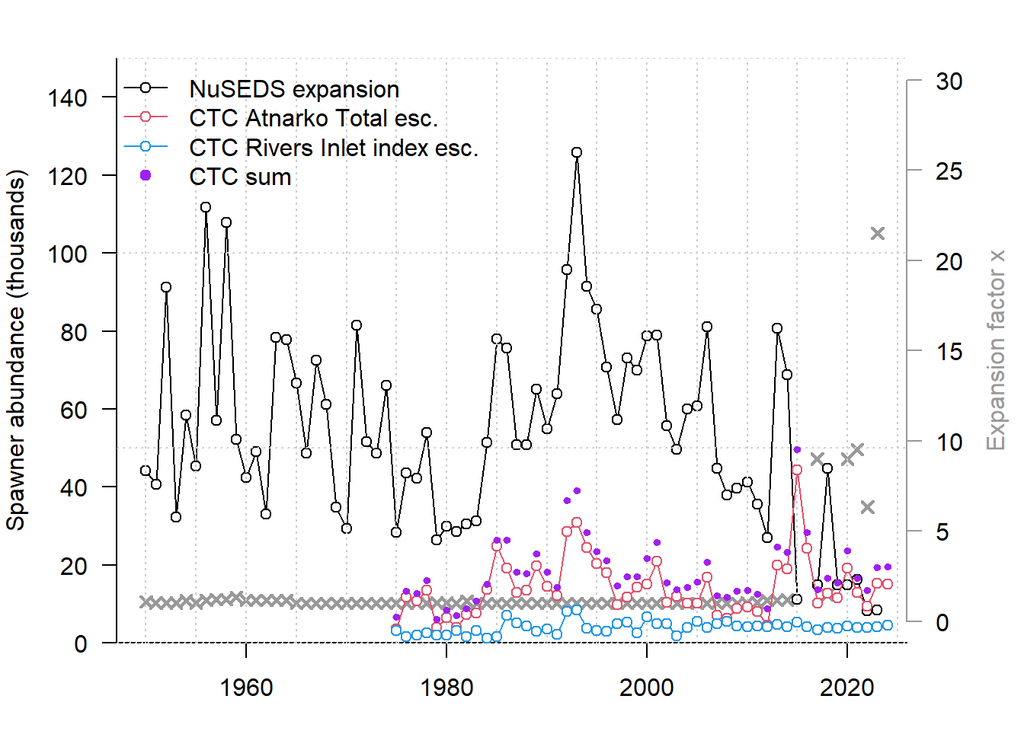

**Above:** Comparison of Chinook escapements on the Central Coast. The sum of Atnarko escapement (red) and Rivers Inlet escapement index (blue) from the CTC (purple points) was used in 2025. The expanded data from NuSEDS, not used, are in black with expansion factors used shown by grey ‘x’

```r
## Code to generate index comparison plot:
# Expanded spawner estimate
ccck_ex <- readRDS("../output/expanded-spawners/Central Coast-spawners.rds")[2, "Chinook", ]
yrs <- as.numeric(names(ccck_ex))

e <- readRDS("../output/expanded-spawners/Central Coast-expansion-factors.rds")[[1]]

# TCCHINOOK Table B3
cc_ctc <- readxl::read_xlsx("../data/TCCHINOOK-25-02-Appendix-B-Escapement-Detailed.xlsx", sheet = "B3",
                                                        range = "H5:K54", col_types = "numeric",
                                                        col_names = c("Atnarko_Total_esc", "Atnarko_CV",
                                                                                    "Atnarko_Wild", "Rivers_Inlet")) %>%
    mutate(Year = c(1975:2024))

par(mar = c(3,4,2,4))
plot(yrs, e$exp1, pch = 4, bty = "n", xaxt = "n", yaxt = "n", xlab = "", ylab = "", col = grey(0.6), ylim = c(0, 30), lwd = 2)
axis(side = 4, col = grey(0.6), las = 1)
mtext(side = 4, line = 2.5, "Expansion factor x", col = grey(0.6))
par(new = TRUE)

plot(yrs, ccck_ex*10^-3, "o", pch = 21, bg = "white", bty = "l", xlab = "", ylab = "Spawner abundance (thousands)", ylim = c(0, 150), las = 1, yaxs = "i")
abline(v = seq(1950, 2025, 5), lty = 3, col = grey(0.8))
abline(h = seq(0, 150, 50), lty = 3, col = grey(0.8))
points(cc_ctc$Year, cc_ctc$Atnarko_Total_esc*10^-3, "o", pch = 21, bg = "white", col = 2)
points(cc_ctc$Year, cc_ctc$Rivers_Inlet*10^-3, "o", pch = 21, bg = "white", col = 4)
points(cc_ctc$Year, cc_ctc$Atnarko_Total_esc*10^-3 + cc_ctc$Rivers_Inlet*10^-3, pch = 19, col = "purple", cex = 0.6)

legend("topleft", col = c(1,2,4, "purple"), c("NuSEDS expansion", "CTC Atnarko Total esc.", "CTC Rivers Inlet index esc.", "CTC sum"), pch = c(rep(21, 3), 19), pt.bg = "white", lwd = c(rep(1, 3),NA), bty = "n")
```